# Integration of connectivity scores of gene expression data and clustering on other data sources

### Between-cluster connectivity

#### Demo for first cluster

For the between-cluster connectivity we will use a certain cluster as a reference set and contrast it with all the other clusters (the query set). In contrast to the within-cluster calculations there will no longer be any overlap between the reference and query sets.

As a demonstration, consider the seventh cluster based on the fingerprints. We chose this cluster because it had a relatively high within-cluster connectivity for the first factor, i.e. the compounds share a (local) pattern in their expression matrix.

```r
refMat <- geneMat[,cut.cluster.fingerprintMat==7]
querMat <- geneMat[,cut.cluster.fingerprintMat!=7]
colnames(refMat)
```

```
## [1] "thioridazine"     "chlorpromazine"   "trifluoperazine"
## [4] "prochlorperazine" "fluphenazine"
```

```r
colnames(querMat)
```

```
##  [1] "metformin"                   "phenformin"
##  [3] "phenyl biguanide"            "estradiol"
##  [5] "dexamethasone"               "verapamil"
##  [7] "exemestane"                  "rofecoxib"
##  [9] "amitriptyline"               "15-delta prostaglandin J2"
## [11] "raloxifene"                  "nordihydroguaiaretic acid"
## [13] "celecoxib"                   "LM-1685"
## [15] "SC-58125"                    "tomelukast"
## [17] "LY-294002"                   "ciclosporin"
## [19] "indometacin"                 "MK-886"
## [21] "prednisolone"                "genistein"
## [23] "fludrocortisone"             "sulindac"
## [25] "exisulind"                   "fulvestrant"
## [27] "staurosporine"               "flufenamic acid"
## [29] "N-phenylanthranilic acid"    "arachidonyltrifluoromethane"
## [31] "trichostatin A"              "diclofenac"
## [33] "fasudil"                     "valproic acid"
## [35] "imatinib"                    "tetraethylenepentamine"
## [37] "clozapine"                   "haloperidol"
## [39] "W-13"                        "arachidonic acid"
## [41] "quinpirole"                  "calmidazolium"
## [43] "dopamine"                    "bucladesine"
## [45] "probucol"                    "resveratrol"
## [47] "butein"                      "nocodazole"
## [49] "4,5-dianilinophthalimide"    "benserazide"
## [51] "tioguanine"
```

```
## Echoufier Rv Correlation:
##           Reference     Query       MFA
## Reference 1.0000000 0.2515774 0.7166931
## Query     0.2515774 1.0000000 0.8552625
## MFA       0.7166931 0.8552625 1.0000000
```

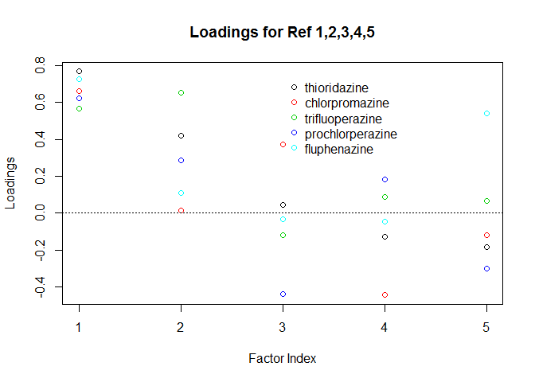

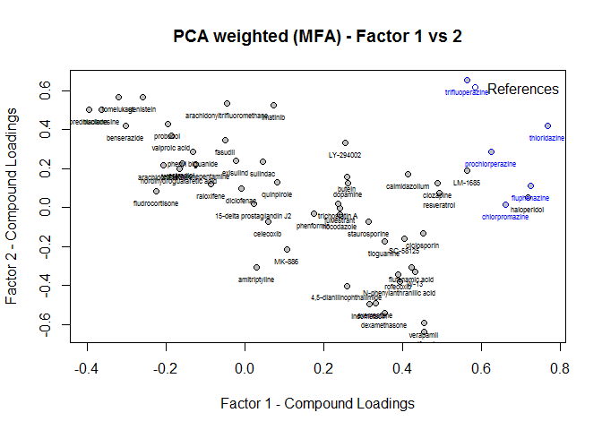

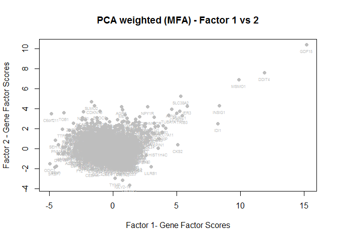

```r
betw.finger.factor1.demo <-  CSanalysis(refMat, querMat,"CSmfa",which=c(2,3),factor.plot=1,plot.type='sweave')
```

```r
# which = 4 gene scores for certain factor
# which =3, gene scores for both factors at once + loadings for both factors
# 5 factor 1 loadings
# 2 both loadings
# 6 expression profiles selection
```

The loadings for the queries, per cluster, for the first component are:

```r
sapply(n.cluster.fingerprint, function(y) betw.finger.factor1.demo@CS$CS.query[colnames(geneMat[,cut.cluster.fingerprintMat==y]),])
```

```
## [[1]]
## [1]  0.4543686  0.1768859 -0.1316894 -0.1236623  0.3552306
##
## [[2]]
## [1] -0.1585565 -0.1638410 -0.2587117  0.2409015  0.2624123 -0.1953525
## [7]  0.4931024  0.2605335
##
## [[3]]
## [1]  0.3553928  0.3329526 -0.3950779 -0.2248632
##
## [[4]]
##  [1]  0.45537813  0.38997162  0.03046278 -0.08482926  0.06039259
##  [6]  0.56447662  0.40480833  0.25502444  0.31566105  0.10862276
## [11]  0.04572269 -0.02124679  0.31341539 -0.04901475  0.07268743
## [16]  0.48987368  0.71763685  0.43356728  0.08354278  0.41359287
## [21]  0.24269666
##
## [[5]]
## [1]  0.02288021 -0.32013097  0.45301713 -0.04411832  0.23710863 -0.18444269
## [7] -0.20556952 -0.36296350 -0.30145194
##
## [[6]]
## [1]  0.423432043  0.394862382 -0.008218568  0.260640317
##
## [[7]]
## [1] NA NA NA NA NA
```

```
## Echoufier Rv Correlation:
##           Reference     Query       MFA
## Reference 1.0000000 0.2515774 0.7166931
## Query     0.2515774 1.0000000 0.8552625
## MFA       0.7166931 0.8552625 1.0000000
```

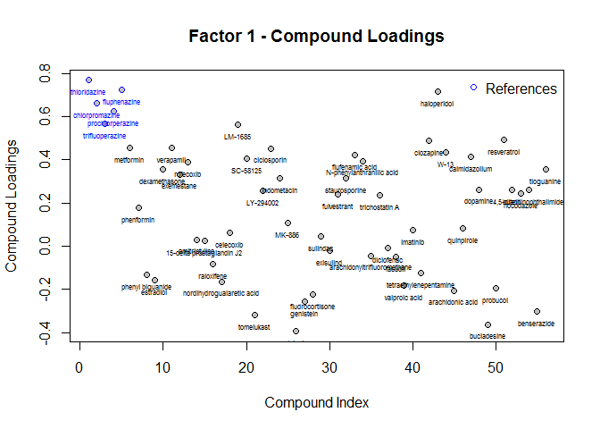

```r
loadings <- CSanalysis(refMat,querMat,"CSmfa",factor.plot=1,which=c(5),
                    result.available=betw.finger.factor1.demo,plot.type='sweave')
```

When we look at the averaged absolute values per cluster, for the first component, it seems that the third cluster is most similar to the reference cluster 7.

```r
sapply(sapply(n.cluster.fingerprint, function(y) betw.finger.factor1.demo@CS$CS.query[colnames(geneMat[,cut.cluster.fingerprintMat==y]),]),function(x) mean(abs(x)))
```

```
## [1] 0.2483673 0.2541764 0.3270716 0.2644107 0.2368537 0.2717883        NA
```

The genes that have the highest factor scores for the first component are GDF15, DDIT4 and MSMO1.

```
## Echoufier Rv Correlation:
##           Reference     Query       MFA
## Reference 1.0000000 0.2515774 0.7166931
## Query     0.2515774 1.0000000 0.8552625
## MFA       0.7166931 0.8552625 1.0000000
```

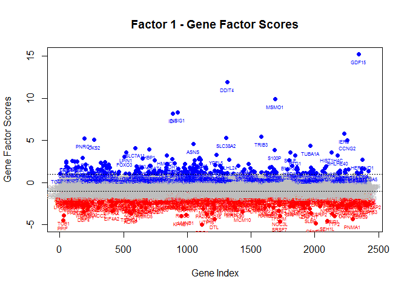

```r
genes<-CSanalysis(refMat,querMat,"CSmfa",factor.plot=1,which=c(4),
                    result.available=betw.finger.factor1.demo,plot.type='sweave')
```

When we consider the second component, the same genes and clusters still appear.

```r
betw.finger.factor2.demo <-  CSanalysis(refMat, querMat,"CSmfa",which=c(),factor.plot=2,plot.type='sweave')
```

```r
sapply(n.cluster.fingerprint, function(y) betw.finger.factor2.demo@CS$CS.query[colnames(geneMat[,cut.cluster.fingerprintMat==y]),])
```

```
## [[1]]
## [1] -0.64024562 -0.03131723  0.28669627  0.22197277 -0.17319280
##
## [[2]]
## [1]  0.228193948  0.200867738  0.565775725 -0.004726074  0.127542689
## [6]  0.429420200  0.074232060  0.155606784
##
## [[3]]
## [1] -0.54190609 -0.48970710  0.50439542  0.08262417
##
## [[4]]
##  [1] -0.59250539 -0.34256322 -0.30619755  0.12219163 -0.07288025
##  [6]  0.19098711 -0.16138603  0.33363001 -0.49527198 -0.21660058
## [11]  0.23628945  0.23920763 -0.07263679  0.34704872  0.52418215
## [16]  0.12494450  0.05014243 -0.32915051  0.12873326  0.16934049
## [21] -0.03756427
##
## [[5]]
## [1]  0.01893067  0.56922046 -0.13279231  0.53403500  0.01960834  0.37107540
## [7]  0.21761224  0.50457503  0.41910508
##
## [[6]]
## [1] -0.30845395 -0.37896106  0.09768578 -0.40186377
##
## [[7]]
## [1] NA NA NA NA NA
```

```r
sapply(sapply(n.cluster.fingerprint, function(y) betw.finger.factor2.demo@CS$CS.query[colnames(geneMat[,cut.cluster.fingerprintMat==y]),]),function(x) mean(abs(x)))
```

```
## [1] 0.2706849 0.2232957 0.4046582 0.2425454 0.3096616 0.2967411        NA
```

```
## Echoufier Rv Correlation:
##           Reference     Query       MFA
## Reference 1.0000000 0.2515774 0.7166931
## Query     0.2515774 1.0000000 0.8552625
## MFA       0.7166931 0.8552625 1.0000000
```

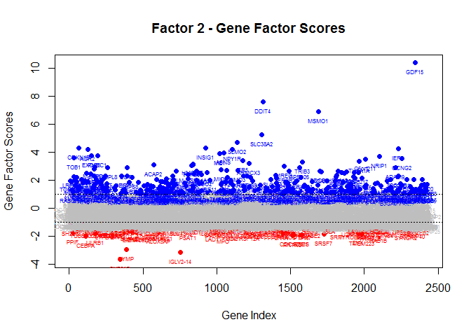

```r
genes<-CSanalysis(refMat,querMat,"CSmfa",factor.plot=2,which=c(4),
                    result.available=betw.finger.factor2.demo,plot.type='sweave')
```

#### Between-connectivity based on fingerprints

Now we will do all of this in a loop.

```r
connectivity.fingerprint.betw <- lapply(n.cluster.fingerprint, function(x) NULL)
ptm <- proc.time()
for (i in 1:length(connectivity.fingerprint.betw)) { # loop through clusters
  connectivity.fingerprint.betw[[i]][['refMat']] <- geneMat[,cut.cluster.fingerprintMat==i] # reference contains i'th cluster
  connectivity.fingerprint.betw[[i]][['querMat']] <- geneMat[,cut.cluster.fingerprintMat!=i] # query set contains all other clusters
  connectivity.fingerprint.betw[[i]][['MFA']] <- CSanalysis(connectivity.fingerprint.betw[[i]][['refMat']],
                                                     connectivity.fingerprint.betw[[i]][['querMat']],
                                                     "CSmfa",which=c(),factor.plot=1) # MFA analysis
}
proc.time() - ptm
```

We will focus on clusters 3 and 7 for the first component, because these showed the highest average within-cluster connectivity.

Note: cluster 5 and 6 show interesting sub-clusters still…

```
## [1] "Reference cluster is 3"
## Echoufier Rv Correlation:
##           Reference     Query       MFA
## Reference 1.0000000 0.3838865 0.7820214
## Query     0.3838865 1.0000000 0.8757056
## MFA       0.7820214 0.8757056 1.0000000
```

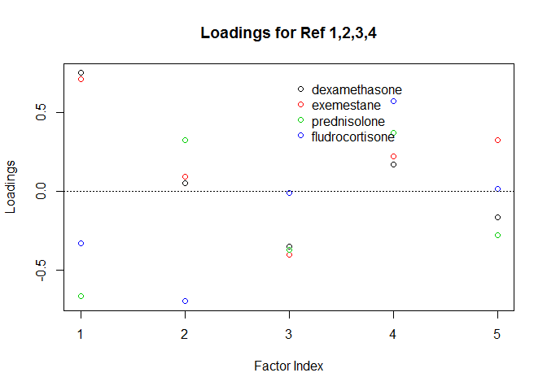

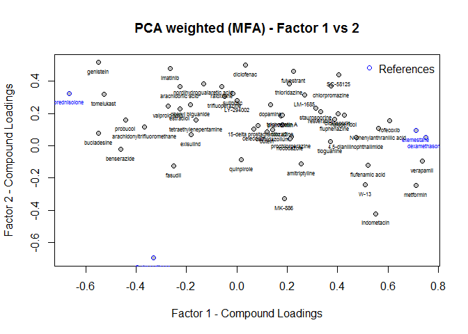

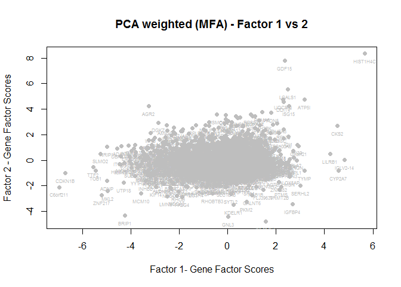

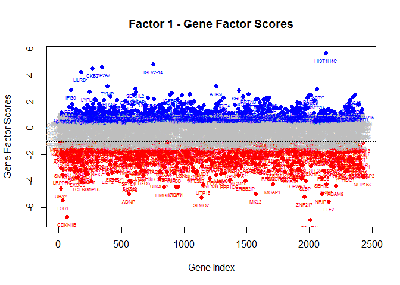

```
## [1] "Reference cluster is 7"
## Echoufier Rv Correlation:
##           Reference     Query       MFA
## Reference 1.0000000 0.2515774 0.7166931
## Query     0.2515774 1.0000000 0.8552625
## MFA       0.7166931 0.8552625 1.0000000
```

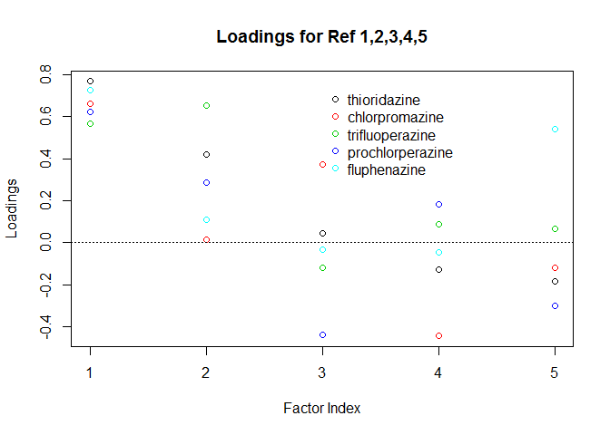

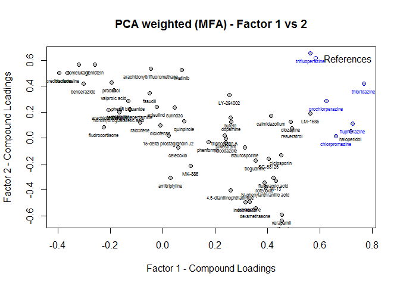

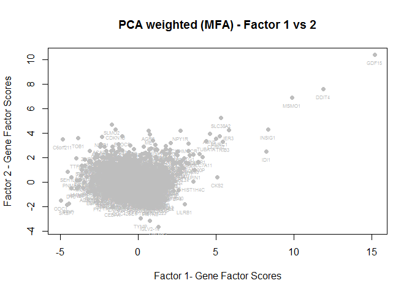

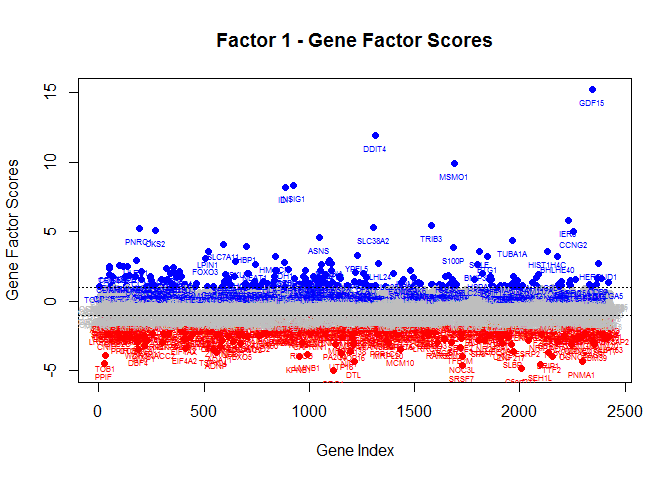

```r
plot_MFA_fingerprint_between = function(cluster,factor){
  # Plots result for already calculated MFA objects
  mfa <- CSanalysis(connectivity.fingerprint.betw[[cluster]][['refMat']],
                    connectivity.fingerprint.betw[[cluster]][['querMat']],
                    "CSmfa",factor.plot=factor,which=c(2,3,4),
                    result.available=connectivity.fingerprint.betw[[cluster]][['MFA']],
                    plot.type='sweave')
  return(mfa)
}
# for (i in 1:length(n.cluster.fingerprint)){
#   print(paste('Reference cluster is',i))
#   plot_MFA_fingerprint_between(i,1)
# }
for (i in c(3,7)) {
  print(paste('Reference cluster is',i))
  plot_MFA_fingerprint_between(i,1)
}
```

##### Average between-cluster connectivity for fingerprints

The average connectivity between clusters based on the first component is (per cluster):

```r
# inner sapply y retrieves query loadings per cluster
# middle sapply z takes average of these per cluster
# outer ssaply does this ones for each cluster as a reference set
sapply(n.cluster.fingerprint, function(x)
  sapply(
    sapply(n.cluster.fingerprint, function(y)
    connectivity.fingerprint.betw[[x]][['MFA']]@CS$CS.query[colnames(geneMat[,cut.cluster.fingerprintMat==y]),]),
    function(z) mean(abs(z))))
```

```
##           [,1]      [,2]      [,3]      [,4]      [,5]      [,6]      [,7]
## [1,]        NA 0.3274932 0.3212115 0.3462621 0.3677392 0.3114870 0.2483673
## [2,] 0.2626802        NA 0.2694606 0.2841706 0.2491528 0.2758107 0.2541764
## [3,] 0.4675385 0.4613610        NA 0.5022134 0.4620597 0.5080120 0.3270716
## [4,] 0.2784712 0.2651032 0.2689865        NA 0.2709914 0.2612065 0.2644107
## [5,] 0.3660819 0.3305303 0.3410710 0.3524639        NA 0.3267361 0.2368537
## [6,] 0.3700567 0.3945142 0.3974821 0.3882393 0.3656247        NA 0.2717883
## [7,] 0.2731922 0.2723131 0.2473608 0.3643615 0.2576063 0.2735159        NA
```

```r
# columns indicate reference cluster
# rows are average query loadings
```

And based on the second component:

```r
redo_MFA_fingerprint_between = function(cluster,factor){
  mfa <- CSanalysis(connectivity.fingerprint.betw[[cluster]][['refMat']],
                    connectivity.fingerprint.betw[[cluster]][['querMat']],
                    "CSmfa",factor.plot=factor,which=c(),
                    result.available=connectivity.fingerprint.betw[[cluster]][['MFA']],
                    plot.type='sweave')
  return(mfa)
}
betw.avg.connectivity.finger.pc2 <- sapply(n.cluster.fingerprint, function(x) sapply(sapply(n.cluster.fingerprint, function(y) redo_MFA_fingerprint_between(x,2)@CS$CS.query[colnames(geneMat[,cut.cluster.fingerprintMat==y]),]),function(z) mean(abs(z))))
# ## Warning in .local(refMat, querMat, type, ...): CS, GS and CSRankScores Slot
## in CSresult will be overwritten due to different factor choice.
```

```r
betw.avg.connectivity.finger.pc2
```

```
##           [,1]      [,2]      [,3]       [,4]      [,5]       [,6]
## [1,]        NA 0.1438225 0.1752034 0.17288453 0.1438013 0.10391760
## [2,] 0.1525567        NA 0.2879301 0.28621163 0.2967699 0.19671459
## [3,] 0.1321774 0.1493657        NA 0.19129994 0.1282185 0.30072075
## [4,] 0.1291917 0.2107487 0.2206895         NA 0.2231410 0.15710398
## [5,] 0.1177334 0.2215028 0.1840480 0.21149004        NA 0.13979990
## [6,] 0.1051035 0.1148145 0.1962307 0.09845516 0.1283296         NA
## [7,] 0.1335386 0.4149423 0.2562600 0.49955215 0.5005061 0.08859619
##           [,7]
## [1,] 0.2706849
## [2,] 0.2232957
## [3,] 0.4046582
## [4,] 0.2425454
## [5,] 0.3096616
## [6,] 0.2967411
## [7,]        NA
```

#### Between-connectivity based on target predictions

```r
connectivity.target.betw <- lapply(n.cluster.target, function(x) NULL)
ptm <- proc.time()
for (i in 1:length(connectivity.target.betw)) { # loop through clusters
  connectivity.target.betw[[i]][['refMat']] <- geneMat[,cut.cluster.targetMat==i] # reference contains i'th cluster
  connectivity.target.betw[[i]][['querMat']] <- geneMat[,cut.cluster.targetMat!=i] # query set contains all other clusters
  connectivity.target.betw[[i]][['MFA']] <- CSanalysis(connectivity.target.betw[[i]][['refMat']],
                                                     connectivity.target.betw[[i]][['querMat']],
                                                     "CSmfa",which=c(),factor.plot=1) # MFA analysis
}
proc.time() - ptm
```

We plot the figures for each cluster-reference set:

```
## [1] "Reference cluster is 1"
## Echoufier Rv Correlation:
##           Reference     Query       MFA
## Reference 1.0000000 0.2867505 0.8108455
## Query     0.2867505 1.0000000 0.7931928
## MFA       0.8108455 0.7931928 1.0000000
```

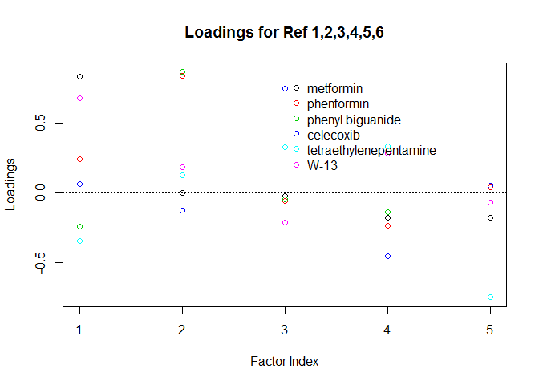

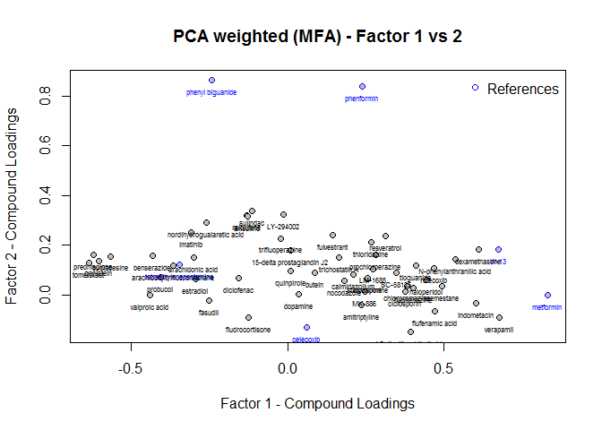

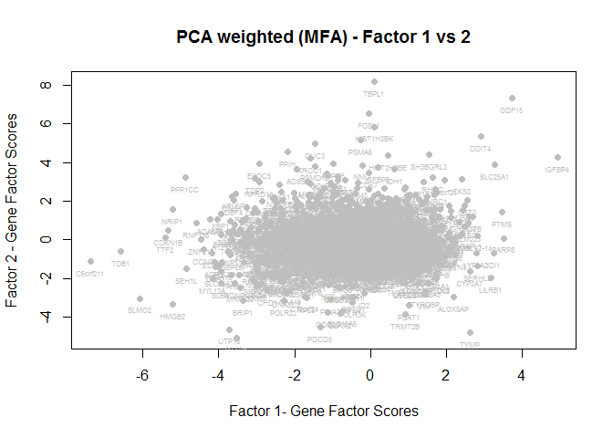

```
## [1] "Reference cluster is 2"
## Echoufier Rv Correlation:
##           Reference    Query       MFA
## Reference 1.0000000 0.378437 0.8066873
## Query     0.3784370 1.000000 0.8523060
## MFA       0.8066873 0.852306 1.0000000
```

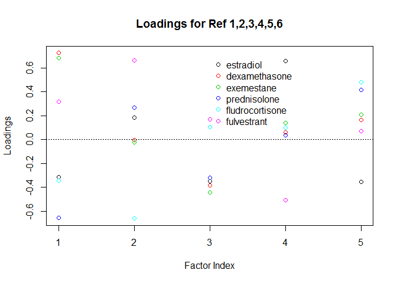

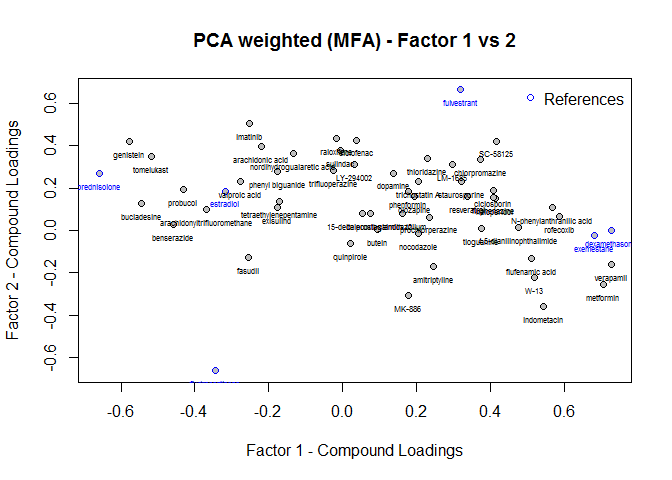

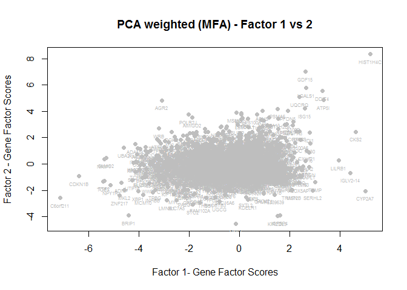

```
## [1] "Reference cluster is 3"
## Echoufier Rv Correlation:
##           Reference     Query       MFA
## Reference 1.0000000 0.2818730 0.7426472
## Query     0.2818730 1.0000000 0.8518606
## MFA       0.7426472 0.8518606 1.0000000
```

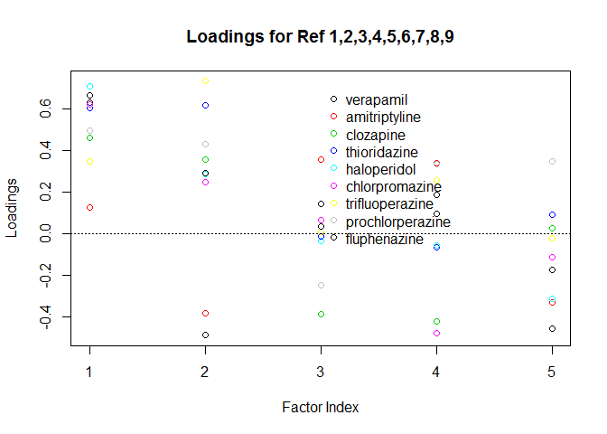

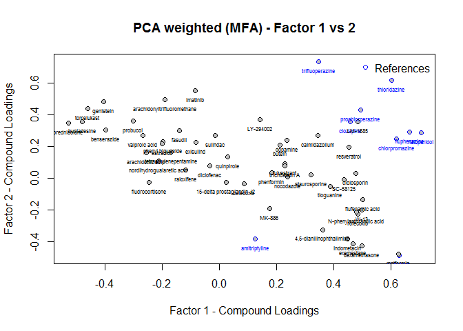

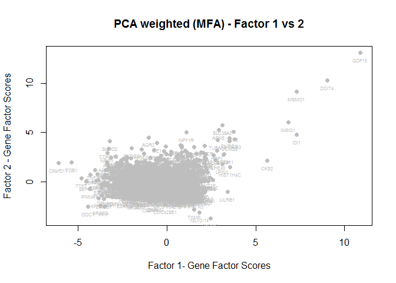

```
## [1] "Reference cluster is 4"
## Echoufier Rv Correlation:
##           Reference     Query       MFA
## Reference 1.0000000 0.3692011 0.8200426
## Query     0.3692011 1.0000000 0.8346297
## MFA       0.8200426 0.8346297 1.0000000
```

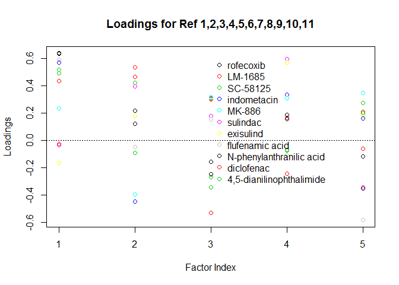

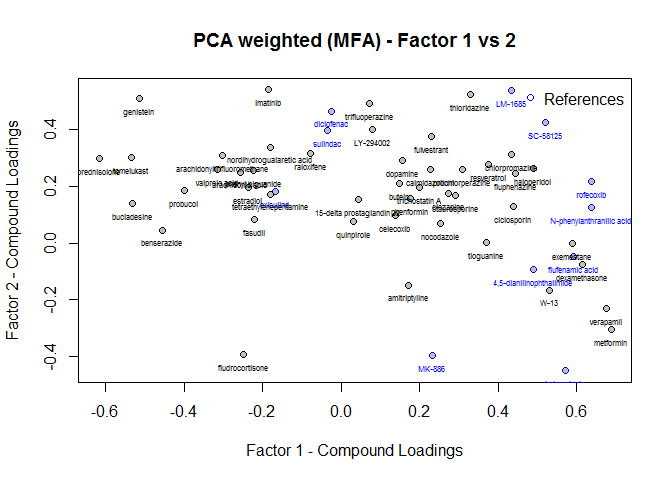

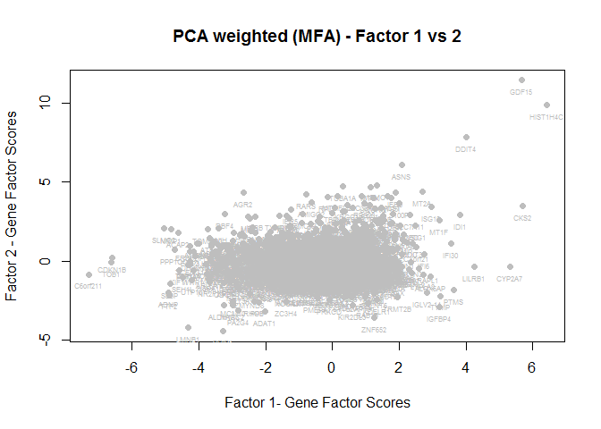

```
## [1] "Reference cluster is 5"
## Echoufier Rv Correlation:
##           Reference     Query       MFA
## Reference 1.0000000 0.2596873 0.7603781
## Query     0.2596873 1.0000000 0.8246593
## MFA       0.7603781 0.8246593 1.0000000
```

[9 more figures not shown]

```r
plot_MFA_target_between = function(cluster,factor){
  # Plots result for already calculated MFA objects
  mfa <- CSanalysis(connectivity.target.betw[[cluster]][['refMat']],
                    connectivity.target.betw[[cluster]][['querMat']],
                    "CSmfa",factor.plot=factor,which=c(2,3),
                    result.available=connectivity.target.betw[[cluster]][['MFA']],
                    plot.type='sweave')
  return(mfa)
}
for (i in 1:length(n.cluster.target)){
  print(paste('Reference cluster is',i))
  plot_MFA_target_between(i,1)
}
```

##### Average between-cluster connectivity for target predictions

The average connectivity between clusters based on the first component is (per cluster):

```r
# columns indicate reference cluster
# rows indicate comparison cluster for that reference
sapply(n.cluster.target, function(x) sapply(sapply(n.cluster.target, function(y) connectivity.target.betw[[x]][['MFA']]@CS$CS.query[colnames(geneMat[,cut.cluster.targetMat==y]),]),function(z) mean(abs(z))))
```

```
##           [,1]      [,2]      [,3]      [,4]      [,5]      [,6]      [,7]
## [1,]        NA 0.3008201 0.2935275 0.3229953 0.3451834 0.3183621 0.3206513
## [2,] 0.3806102        NA 0.3615844 0.4227133 0.3234766 0.3785199 0.3984148
## [3,] 0.3289115 0.3167904        NA 0.3552865 0.2657988 0.3201147 0.3655958
## [4,] 0.3392044 0.3453295 0.3183407        NA 0.3053993 0.3403816 0.3255025
## [5,] 0.3496888 0.2917153 0.2402079 0.2913703        NA 0.3231952 0.3049236
## [6,] 0.2528877 0.2452358 0.2630911 0.2598168 0.2562269        NA 0.2468110
## [7,] 0.2733375 0.2762951 0.2840957 0.2801179 0.2560387 0.2549403        NA
```

```r
# the outer sapply loops through cluster numbers x
# i.e. a different reference cluster each time

# inner sapply loops through cluster numbers y, for a given cluster z
# and extracts the loadings for each of the query clusters y into separate lists (NA for cluster x)
# i.e. 7 lists in total
str(sapply(n.cluster.target, function(y) connectivity.target.betw[[3]][['MFA']]@CS$CS.query[colnames(geneMat[,cut.cluster.targetMat==y]),]))
```

```
## List of 7
##  $ : num [1:6] 0.6267 0.1827 -0.1978 0.0875 -0.1687 ...
##  $ : num [1:6] -0.201 0.498 0.467 -0.529 -0.246 ...
##  $ : num [1:9] NA NA NA NA NA NA NA NA NA
##  $ : num [1:11] 0.484 0.484 0.437 0.447 0.175 ...
##  $ : num [1:5] 0.0248 -0.4616 -0.1907 -0.2682 -0.2556
##  $ : num [1:9] -0.1175 -0.2124 -0.4063 0.0286 0.2362 ...
##  $ : num [1:10] 0.141 0.477 0.32 0.228 -0.14 ...
```

```r
# next level of sapply takes the mean absolute value of each list
# by looping through each list z of the inner sapply
# i.e. 7 averages
str(sapply(sapply(n.cluster.target, function(y) connectivity.target.betw[[3]][['MFA']]@CS$CS.query[colnames(geneMat[,cut.cluster.targetMat==y]),]),function(z) mean(abs(z))))
```

```
##  num [1:7] 0.294 0.362 NA 0.318 0.24 ...
```

```r
sapply(sapply(n.cluster.fingerprint, function(y) betw.finger.factor1.demo@CS$CS.query[colnames(geneMat[,cut.cluster.fingerprintMat==y]),]),function(x) mean(abs(x)))
```

```
## [1] 0.2483673 0.2541764 0.3270716 0.2644107 0.2368537 0.2717883        NA
```

```r
connectivity.target.betw[[3]][['MFA']]@CS$CS.query
```

```
##                                 Factor1
## metformin                    0.62672418
## phenformin                   0.18272471
## phenyl biguanide            -0.19776999
## estradiol                   -0.20125000
## dexamethasone                0.49801917
## exemestane                   0.46686033
## rofecoxib                    0.48408855
## 15-delta prostaglandin J2    0.02479019
## raloxifene                  -0.11753599
## nordihydroguaiaretic acid   -0.21239078
## celecoxib                    0.08750246
## LM-1685                      0.48386674
## SC-58125                     0.43719113
## tomelukast                  -0.46164910
## LY-294002                    0.14079455
## ciclosporin                  0.47688794
## indometacin                  0.44743642
## MK-886                       0.17480256
## prednisolone                -0.52948819
## genistein                   -0.40625552
## fludrocortisone             -0.24622018
## sulindac                    -0.01395311
## exisulind                   -0.08238805
## fulvestrant                  0.22766876
## staurosporine                0.31977885
## flufenamic acid              0.50160010
## N-phenylanthranilic acid     0.47988857
## arachidonyltrifluoromethane -0.19074720
## trichostatin A               0.22751480
## diclofenac                  -0.03431434
## fasudil                     -0.13999069
## valproic acid               -0.26821196
## imatinib                    -0.08455564
## tetraethylenepentamine      -0.16873292
## W-13                         0.49771102
## arachidonic acid            -0.25564091
## quinpirole                   0.02855355
## calmidazolium                0.34490578
## dopamine                     0.23616555
## bucladesine                 -0.48100172
## probucol                    -0.30318314
## resveratrol                  0.45397556
## butein                       0.21188116
## nocodazole                   0.23728587
## 4,5-dianilinophthalimide     0.36221830
## benserazide                 -0.39787835
## tioguanine                   0.38824147
```

```r
colnames(geneMat[,cut.cluster.targetMat==3])
```

```
## [1] "verapamil"        "amitriptyline"    "clozapine"
## [4] "thioridazine"     "haloperidol"      "chlorpromazine"
## [7] "trifluoperazine"  "prochlorperazine" "fluphenazine"
```

```r
str(sapply(n.cluster.target, function(y) connectivity.target.betw[[3]][['MFA']]@CS$CS.query[colnames(geneMat[,cut.cluster.targetMat==y]),]))
```

```
## List of 7
##  $ : num [1:6] 0.6267 0.1827 -0.1978 0.0875 -0.1687 ...
##  $ : num [1:6] -0.201 0.498 0.467 -0.529 -0.246 ...
##  $ : num [1:9] NA NA NA NA NA NA NA NA NA
##  $ : num [1:11] 0.484 0.484 0.437 0.447 0.175 ...
##  $ : num [1:5] 0.0248 -0.4616 -0.1907 -0.2682 -0.2556
##  $ : num [1:9] -0.1175 -0.2124 -0.4063 0.0286 0.2362 ...
##  $ : num [1:10] 0.141 0.477 0.32 0.228 -0.14 ...
```

```r
sum(sapply(sapply(n.cluster.target, function(y) connectivity.target.betw[[3]][['MFA']]@CS$CS.query[colnames(geneMat[,cut.cluster.targetMat==y]),]),function(y) length(y)))
```

```
## [1] 56
```

```r
str(connectivity.target.betw[[3]][['MFA']]@CS$CS.query)
```

```
## 'data.frame':    47 obs. of  1 variable:
##  $ Factor1: num  0.627 0.183 -0.198 -0.201 0.498 ...
```

```r
mean(abs(connectivity.target.betw[[3]][['MFA']]@CS$CS.query[,1]))
```

```
## [1] 0.2945157
```

```r
# No need to loop through clusters a second time, since CS.query only contains loadings for the other (=query) clusters
# Just loop through outer clusters and retrieve all queries?
```

And based on the second component:

```r
redo_MFA_target_between = function(cluster,factor){
  mfa <- CSanalysis(connectivity.target.betw[[cluster]][['refMat']],
                    connectivity.target.betw[[cluster]][['querMat']],
                    "CSmfa",factor.plot=factor,which=c(),
                    result.available=connectivity.target.betw[[cluster]][['MFA']],
                    plot.type='sweave')
  return(mfa)
}
betw.avg.connectivity.target.pc2 <- sapply(n.cluster.target, function(x) sapply(sapply(n.cluster.target, function(y) redo_MFA_target_between(x,2)@CS$CS.query[colnames(geneMat[,cut.cluster.targetMat==y]),]),function(z) mean(abs(z))))
# ## Warning in .local(refMat, querMat, type, ...): CS, GS and CSRankScores Slot
## in CSresult will be overwritten due to different factor choice.
```

```r
betw.avg.connectivity.target.pc2
```

```
##           [,1]      [,2]      [,3]      [,4]      [,5]      [,6]      [,7]
## [1,]        NA 0.1918898 0.1907924 0.1915679 0.1511986 0.1373982 0.1466919
## [2,] 0.1291652        NA 0.2531391 0.2226864 0.1928777 0.1956543 0.1582174
## [3,] 0.1022514 0.2012839        NA 0.2936113 0.3573586 0.2436638 0.3318231
## [4,] 0.1295029 0.2398889 0.2191119        NA 0.2111399 0.1893573 0.1490255
## [5,] 0.1152626 0.2301953 0.2780195 0.2536112        NA 0.2244272 0.2514780
## [6,] 0.1555990 0.2148214 0.2313700 0.2490674 0.2507610        NA 0.2725508
## [7,] 0.1237753 0.1818474 0.2029358 0.1978347 0.2297505 0.2421406        NA
```

## Promising reading materials

- [Use of chemical similarity in drug discovery](http://mcc.irb.hr/mcc_04/presentations/butina_d_mcc04_2.pdf)
- [ChemmineR](https://www.bioconductor.org/packages/3.3/bioc/vignettes/ChemmineR/inst/doc/ChemmineR.html#introduction) and [tutorial](http://chemmine.ucr.edu/help/):
  - contains modules for similarity searching of chemical compounds (Tanimoto coefficient)
  - clustering of compounds by structural and physicochemical similarities is a powerful approach for correlating structural features of compounds with their activities
- textbook on clustering in drug discovery
- Some cross-validated links:
  - [frequent item set better than clustering?](https://stats.stackexchange.com/questions/86318/clustering-a-binary-matrix)
  - [ordinal vs nominal binary](https://stats.stackexchange.com/questions/116856/hierarchical-or-two-step-cluster-analysis-for-binary-data?rq=1) does the simultaneous absence of both attributes convey any information?
  - [hierarchical clustering](https://stats.stackexchange.com/questions/2717/clustering-with-a-distance-matrix?rq=1)
  - [more clustering options for boolean](https://stats.stackexchange.com/questions/70113/cluster-large-boolean-dataset?rq=1)
- References for clustering:
  - http://handsondatascience.com/ClustersO.pdf

# References

Hastie, Trevor, Robert Tibshirani, and J. H. Friedman. 2009. *The Elements of Statistical Learning: Data Mining, Inference, and Prediction*. 2nd ed. Springer Series in Statistics. New York, NY: Springer.

Lamb, J. 2006. “The Connectivity Map: Using Gene-Expression Signatures to Connect Small Molecules, Genes, and Disease.” *Science* 313 (5795): 1929–35. doi:10.1126/science.1132939.

MacCuish, John D., and Norah E. MacCuish. 2011. *Clustering in Bioinformatics and Drug Discovery*. Chapman & Hall/CRC Mathematical and Computational Biology Series. Boca Raton, FL: CRC Press.

Zhang, Shu-Dong, and Timothy W Gant. 2008. “A Simple and Robust Method for Connecting Small-Molecule Drugs Using Gene-Expression Signatures.” *BMC Bioinformatics* 9 (1): 258. doi:10.1186/1471-2105-9-258.